ORIGINAL ARTICLE

From the Lab to Patients: a Systematic Review and Meta-Analysis

of Mesenchymal Stem Cell Therapy for Stroke

Manoj M. Lalu<sup>1,2,3</sup>

& Joshua Montroy<sup>2</sup>& Dar Dowlatshahi<sup>2,4</sup>& Brian Hutton<sup>5,6</sup>& Pascale Juneau<sup>2</sup>& Neil Wesch<sup>2</sup>&

Sarah Y. Zhang<sup>7</sup>& Ryan McGinn<sup>1,7</sup>& Dale Corbett<sup>3,8</sup>& Duncan J. Stewart<sup>3,9</sup>& Dean A. Fergusson<sup>2,5</sup>

Received: 15 April 2019 /Revised: 3 September 2019 /Accepted: 4 September 2019

# Springer Science+Business Media, LLC, part of Springer Nature 2019

Abstract

There may be the potential to improve stroke recovery with mesenchymal stem cells (MSCs); however, questions about the

efficacy and safety of this treatment remain. To address these issues and inform future studies, we performed a preclinical and

clinical systematic review of MSC therapy for subacute and chronic ischemic stroke. MEDLINE, Embase, the Cochrane Register

of Controlled Trials, and PubMed were searched. For the clinical review, interventional and observational studies of MSC therapy

in ischemic stroke patients were included. For the preclinical review, interventional studies of MSC therapy using in vivo animal

models of subacute or chronic stroke were included. Measures of safety and efficacy were assessed. Eleven clinical and 76

preclinical studies were included. Preclinically, MSC therapy was associated with significant benefits for multiple measures of

motor and neurological function. Clinically, MSC therapy appeared to be safe, with no increase in adverse events reported (with

the exception of self-limited fever immediately following injection). However, the efficacy of treatment was less apparent, with

significant heterogeneity in both study design and effect size being observed. Additionally, in the only randomized phase II study

to date, efficacy of MSC therapy was not observed. Preclinically, MSC therapy demonstrated considerable efficacy. Although

MSC therapy demonstrated safety in the clinical setting, efficacy has yet to be determined. Future studies will need to address the

discordance in the continuity of evidence as MSC therapy has been translated from “bench-to-bedside”.

Keywords Stem cells <sup>.</sup>Stroke <sup>.</sup>Ischemic stroke <sup>.</sup>Systematic review <sup>.</sup>Clinical <sup>.</sup>Preclinical

Introduction

Worldwide, stroke is the second leading cause of death and

the third leading cause of disability with ischemic causes

accounting for almost 85% of all stroke cases [1, 2].

Despite the massive societal and economic burden of stroke,

treatments remain limited. Currently, tissue plasminogen

activator (tPA) and mechanical thrombectomy are the only

validated therapeutic interventional treatments for ischemic

stroke patients [3].

Electronic supplementary material The online version of this article

(https://doi.org/10.1007/s12975-019-00736-5) contains supplementary

material, which is available to authorized users.

* Manoj M. Lalu

mlalu@toh.ca

1

Department of Anesthesiology and Pain Medicine, The Ottawa

Hospital Research Institute, Room B307, 1053 Carling Ave, Mail

Stop 249, Ottawa, ON K1Y 4E9, Canada

2

Clinical Epidemiology Program, Blueprint Translational Group, The

Ottawa Hospital Research Institute, Ottawa, Canada

3

Department of Cellular and Molecular Medicine, University of

Ottawa, Ottawa, Canada

4

Department of Medicine, Neurology, The Ottawa Hospital,

Ottawa, Canada

5

Knowledge Synthesis Group, Ottawa Hospital Research Institute,

Ottawa, Canada

6

School of Epidemiology and Public Health, University of Ottawa,

Ottawa, Canada

7

Faculty of Medicine, University of Ottawa, Ottawa, Canada

8

Canadian Partnership for Stroke Recovery, Ottawa, Canada

9

Regenerative Medicine Program, Ottawa Hospital Research Institute,

Ottawa, Canada

https://doi.org/10.1007/s12975-019-00736-5

Translational Stroke Research (2020) 11:345–364

/Published online:

3

25 October 2019

While long-term recovery from stroke is possible, accepted

therapies to date are most optimal when initiated during a critical

acute time window for recovery post-stroke [4]. By three months

post-stroke, the rate of recovery rapidly decelerates and typically

plateaus at approximately six months; this has often been referred

to as a “closing of the window of recovery” [5, 6]. Recent ad-

vances in regenerative medicine suggest that there may be the

possibility for enhanced recovery following stroke, and stem cell

therapies may in fact reopen and/or expand the window of re-

covery following stroke [7].

Mesenchymal stem cells (MSCs) are one such promising

cell therapy. MSCs can modulate tissue injury and inflamma-

tion [8, 9]. In preclinical studies using in vivo models of is-

chemic stroke, administration of MSCs has resulted in en-

hanced recovery of sensorimotor function [10], promotion of

synaptogenesis, stimulation of nerve regeneration [11], de-

creased tissue plasminogen activator-induced brain damage

[12], and favorable immunomodulatory effects [13].

Clinically, MSC administration has been shown to be safe in

the stroke population in small, early phase trials [7, 14].

However, questions about the efficacy of MSC treatment for

subacute and chronic stroke remain [15].

Before further resource-intensive clinical trials are under-

taken, it is imperative that an up-to-date, methodologically

rigorous review of the current literature is performed in order

to analyze the safety and efficacy of MSC therapy in preclin-

ical and clinical stroke. This may identify knowledge gaps

along the bench-to-bedside continuum, which may inform

and improve the design of future studies. Moreover, given that

chronic stroke is one of the top five conditions that patients

seek MSC treatment for in international, for-profit, cell thera-

py clinics [16, 17], it is imperative that an objective, current

overview is available for patients and clinicians. Therefore,

the purpose of this systematic review is to evaluate the safety

and efficacy of MSC therapy for ischemic stroke, both in the

preclinical and clinical settings.

Methods

We conducted two systematic reviews, one clinical and one

preclinical. The clinical review was registered on PROSPERO

(CRD42016033503). The preclinical review protocol was

posted a priori on CAMARADES (http://www.camarades.

info). This final manuscript was prepared in accordance with

the PRISMA checklist (Supplemental Table 1) [18].

Eligibility Criteria

For clinical studies, we included both interventional and ob-

servational studies that compared MSC therapy to placebo,

standard of care, or no treatment in chronic or acute ischemic

stroke patients. We used the criteria defined by the

International Society for Cellular Therapy as a general guide

to define MSCs [19]. Studies using MSCs that were differen-

tiated to other cell types, were administered as part of a co-

treatment with other cell types or experimental therapies, or

that had been genetically modified were excluded.

For preclinical studies, we included all controlled interven-

tional studies that compared MSC therapy to placebo/vehicle

or no treatment in preclinical in vivo models of ischemic

stroke. In order to be included, animals in the control arm must

have had a stroke induced (studies with only treatment and

sham arms were not eligible for inclusion). We used the

criteria defined by the International Society for Cellular

Therapy as a general guide to define MSCs [19]. To match

the non-acute stroke setting in humans, MSCs had to be ad-

ministered ≥ 3 days after induction of stroke. If multiple doses

were used, the first dose must have been administered no

earlier than 3 days. Differentiated MSCs, MSCs administered

as part of a co-treatment with other cell types or therapies, or

MSCs which had been genetically modified were excluded.

Outcomes

Our primary outcome in the clinical review was safety, as

characterized by adverse events. Adverse events were record-

ed and grouped by the organ system affected as well as clas-

sified as either immediate (< 24 h) or long term (> 24 h).

Adverse events recorded included the following: fever, stroke,

cardiovascular, neurological, hematological, gastrointestinal,

renal, infectious, and local complications. Long-term adverse

events (i.e., malignancy and death) were also recorded. Our

secondary outcome of interest was efficacy, measured by as-

sessments of neurological function (e.g., Barthel Index (BI)

[20], National Institutes of Health Stroke Scale (NIHSS) [21],

Modified Rankin Scale (mRS) [22]).

In the preclinical setting, our primary outcomes of interest

were measures of skilled forelimb and hind limb function (walk-

ing tasks, skilled reaching tests, adhesive removal test), as these

are considered sensitive tests of motor function [23, 24] and align

with consensus guidelines on preclinical stroke recovery research

[25]. Secondary outcomes of interest included other measures of

neurological status (rotarod, modified neurological severity

score) and safety (mortality and adverse events).

Literature Search Strategy

Two comprehensive literature search strategies (one for clini-

cal studies and one for preclinical studies) were developed in

collaboration with an information specialist (Risa Shorr, MLS,

Ottawa Hospital Library Services) and a clinical expert in the

field of stroke research (DD). A second information specialist

reviewed the search strategies according to the PRESS frame-

work [26]. The final search strategies were used to search

MEDLINE, Embase, The Cochrane Central Register of

Transl. Stroke Res. (2020) 11:345–364

346

Controlled Trials (clinical review only), and PubMed.

Clinicaltrials.gov and www.strokecenter.org/trials/ were also

searched to identify ongoing clinical trials. We did not impose

any language or date restriction on our searches. The search

was last updated on April 20, 2018. Search strategies from

both the clinical and preclinical searches of MEDLINE are

provided in Supplemental Methods 1.

Study Selection Process

All citations identified by our literature searches were

imported into DistillerSR® (Evidence Partners, Ottawa,

Canada). Titles and abstracts were screened for inclusion by

two independent reviewers. Those deemed potentially rele-

vant were recorded, and the full-text articles obtained. Two

independent reviewers then screened the full-text articles for

final eligibility. Any disagreements were settled by consulta-

tion with a senior team member (MML). Although systematic

reviews were not eligible for inclusion, their reference lists

were reviewed to identify additional relevant articles.

Data Extraction

Two independent reviewers extracted relevant data from in-

cluded studies using a standardized and pilot-tested data ex-

traction form, created in DistillerSR<sup>®</sup>. Reviewers collected

data relating to the study characteristics, study populations,

intervention characteristics, outcomes, and risk of bias. Any

disagreements were settled by consultation with a senior team

member (MML).

Risk of Bias Assessment and Construct Validity

For clinical studies, the risk of bias was assessed in duplicate

using the appropriate Cochrane Risk of Bias tool: the RCT

tool for randomized studies, and the ROBINS-I for non-

randomized studies. For preclinical studies, risk of bias was

assessed in duplicate using a modified version of the

Cochrane Risk of Bias Tool that we have previously used

for preclinical systematic reviews [27]. In addition to the risk

of bias, we assessed construct validity for preclinical studies,

to evaluate the clinical generalizability of the experimental

conditions. This is of particular importance since a mismatch

between the preclinical experimental conditions and the clin-

ical manifestation of the disease may result in false estimates

of effect [28]. Construct validity items evaluated in each study

included (1) use of adult animals, (2) use of animals with

relevant comorbidities, (3) evidence of persistent impairment,

(4) rehabilitation of animals, (5) use of a battery of sensory-

motor recovery tests (as opposed to a single test), and (6) size

of infarct. Each item was assigned either a “yes,” “no,” or

“unclear.”

Data Analysis

Studies were pooled using Comprehensive Meta-Analysis

(version 3; Biostat Inc., USA). Dichotomous safety outcomes

were analyzed via fixed effects meta-analyses using Peto odds

ratios and presented with accompanying 95% confidence in-

tervals. Peto’s method was used due to the rarity of events

[29]. For continuous outcomes, a mean difference (MD) or

standardized mean difference (SMD) was calculated, depen-

dent on the outcome. MD and SMD were calculated using

random effects inverse variance meta-analyses and presented

with accompanying 95% confidence intervals. Statistical het-

erogeneity was assessed using the I<sup>2</sup>statistic, as well as the

chi<sup>2</sup>test or the Cochrane Q test, depending on the analysis

method. The presence of publication bias was assessed using

funnel plots when sufficient data was available.

For preclinical studies, where sufficient data were avail-

able, we performed a priori defined subgroup analyses on

the primary outcomes to determine whether the effect of

MSCs on animal function varied by species, stroke induction

model, MSC source, MSC compatibility, timing, or route of

administration. Sensitivity analyses were performed to re-

move extreme values thought to be driving the overall effect,

where applicable.

Assessment of the Continuity of Evidence

We first performed a cross-citation analysis to assess the evidence

base used to justify clinical translation (and evaluate the continu-

ity of evidence from the preclinical to clinical setting).

Bibliographies of included clinical studies were examined to

determine which included preclinical or clinical studies had been

cited. Next, we used the Accumulating Evidence and Research

Organization (AERO) model, to visually represent the totality of

evidence and consistency of results along the preclinical to clin-

ical translational pathway [30]. This model plots the accumulated

evidence over time and stratifies it by study phase (i.e., preclin-

ical, phase I, phase II, etc.). Each study is represented visually by

a circle, with the color of the circle representing the success of the

study (green, yellow, or red). Study success was determined by a

combination of statistical significance of results and study author

conclusions.

Deviations from Protocol

In the preclinical review, tertiary outcomes listed in the proto-

col are not reported in this review. These outcomes (e.g., ves-

sel density, dendritic spine density) were not reported in the

included studies. Planned exploratory subgroup analyses of

biological sex, presence of comorbidities, duration of occlu-

sion, and use of co-interventions were not performed due to

either insufficient data or inconsistent reporting. In the clinical

Transl. Stroke Res. (2020) 11:345–364

347

review, the tertiary outcome of infarct volume was inconsis-

tently reported in included studies, and therefore not analyzed.

Results

A total of 2287 and 1913 references were identified by the

electronic searches for clinical and preclinical studies, respec-

tively. Upon completion of the screening process, a total of 11

citations from 10 clinical studies [7, 14, 15] [S1–8], and 76

preclinical studies were included in our review (Fig. 1) [S9–84].

Characteristics of Included Clinical and Preclinical

Studies

Clinical studies were published between 2009 and 2017 from

six different countries and consisted of six interventional stud-

ies (3 RCTs and 3 non-RCTs) and 4 observational studies (3

case series and 1 retrospective cohort study) (Table 1). Study

sample sizes ranged from 4 patients to 129 patients, and the

duration of follow-up ranged from 24 to 208 weeks.

Preclinical studies were published between 2000 and 2018

from 12 different countries (Table 2). Study sample sizes

ranged from 8 animals to 149 animals. Seventy-four studies

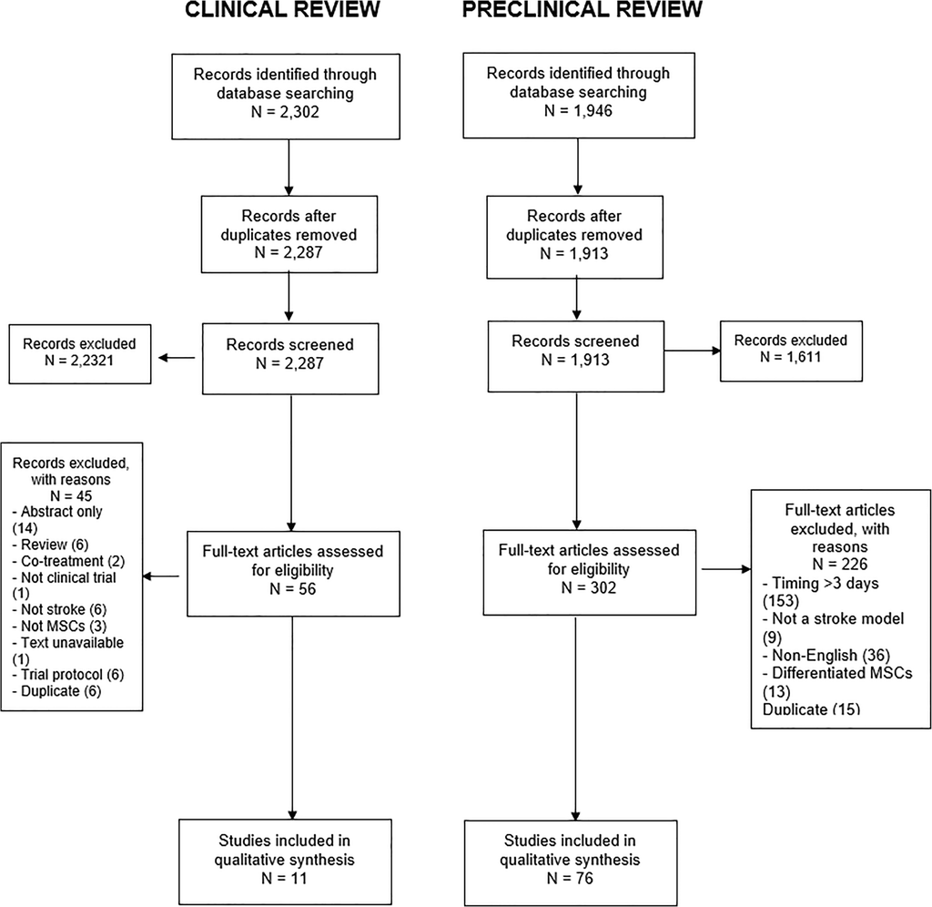

Fig. 1 Study selection flow diagram

Transl. Stroke Res. (2020) 11:345–364

348

Table 1

Clinical study characteristics

Author (year)

Study type

Country

Patients included Intervention (donor

origin, tissue origin,

fresh or frozen)

Administration

route and timing

Dose (total cells)

Comparison

Follow-up

duration (weeks)

Interventional

Hess (2017) [15]

RCT

USA, UK

129

Allogeneic, BM, frozen

IV, 24–48 h

4 × 108-12 × 108

Placebo

52

Bhasin (2017 and 2011) [S4–5] NRCT

USA, India

12

Autologous, BM, fresh

IV, 9.3 months (7–12 months) 5-6 × 107

Standard

rehabilitation

208

Steinberg (2016) [7]

NRCT

USA

18

Allogeneic, BM, NR

IC, 22 months (7–36 months)

2.5 × 106, 5.0 × 106,

or 10 × 106

N/A

52

Chen (2012) [S6]

NRCT

China

60

Autologous, BM, unclear IV, 2 and 4 weeks

3-5 × 106

Standard

rehabilitation

26

Lee (2010) [14]

RCT

South Korea

52

Autologous, BM, fresh

IV, 5 and 7 weeks

5 × 107

Standard

rehabilitation

118

Meng (2009) [S7]

RCT

China

60

Autologous, BM, fresh

IV, NR

16.2–51.3 × 108

Standard

rehabilitation

24

Observational

Wanamaker (2015) [S3]

Cohort

USA

10

NR, NR, NR

IC, 6–60 months

NR

Healthy Control,

No treatment

52

Qiao (2014) [S2]

Case Series China

6

Allogeneic, UB, NR

IV, 8 or 12 weeks

3.75 × 107

No comparison

104

Jiang (2013) [S1]

Case Series China

4

Allogeneic, UB, fresh

IA, 1–7 weeks

2 × 107

No comparison

26

Honmou (2011) [S8]

Case Series Japan

12

Autologous, BM, frozen

IV, 9 weeks

0.6–1.8 × 108

No comparison

52

Transl. Stroke Res. (2020) 11:345–364

349

Table 2

Preclinical study characteristics

Author

Country

Sample

size

Species, strain

Stroke model

MSC source

Timing of

administration

(days post-

stroke)

Dose

Route of

administration

Follow-up

(days)

Chau, 2018 [S11]

USA

16

Mouse, C57BL/6

MCA ligation,

permanent;

CCA

ligation,

transient

Fresh, BM,

xenogeneic

3

1e6

IN

14

Kho, 2018 [S12]

South

Korea

78

Rat, Sprague-Dawley

Intraluminal

suture,

transient

Frozen,

placental,

xenogeneic

7

1e6

IV

28

Zhang, 2018 [S13]

China

36

Rat, Sprague-Dawley

MCAO,

permanent

Fresh, BM,

allogeneic*

7

0.5−3e6

IC, IV, IA

42

*Ding, 2017 [S14]

USA

16

Rat, Wistar

MCAO,

transient

NR, BM,

unclear

3

5e6

IV

35

He, 2017 [S15]

France

32

Rat, Sprague-Dawley

MCAO,

transient

Fresh, BM,

xenogeneic

8

3e6

IV

16

Hu, 2017 [S16]

China

24

Rat, Sprague-Dawley

MCAO,

permanent

Fresh, BM,

allogeneic

9

1e6

IV

14

Huang, 2017 [S17]

China

20

Rat, Sprague-Dawley

MCAO,

transient

Fresh, BM,

allogeneic

3

2e6

IV

14

Ding, 2016 [S18]

USA

16

Rat, Wistar

MCAO,

transient

NR, BM,

unclear

3

5e6

IV

35

He, 2016 [S19]

China

NR

Rat, Sprague-Dawley

MCAO,

permanent

NR, BM,

allogeneic

3

5e4, 5e5, 2e6

IV

7

Lee, 2016 [S20]

South

Korea

28

Rat, Sprague-Dawley

MCAO,

permanent

Fresh, adipose

tissue,

xenogeneic

1, 4, 7

3 × 10e6

IV

28

Moisan, 2016 [S21]

France

78

Rat, Sprague-Dawley

MCAO,

transient

Frozen, BM,

xenogeneic

8

3e6

IV

49

Nam, 2016 [S22]

South

Korea

15

Rat, Sprague-Dawley

MCAO,

permanent

Fresh, BM,

xenogeneic

3

2e6

IV

7

Pourheydar, 2016

[S23]

Iran

40

Rat, Wistar

CCA suture,

transient

Fresh, BM,

allogeneic

7

1e6

IV

10

Zhang, 2016 [S24]

China

120

Rat, Sprague-Dawley

MCAO,

permanent

Frozen, BM,

allogeneic

3

5e5

IC

28

Acosta, 2015 [S25]

USA

30

Rat, Sprague-Dawley

MCAO,

transient

Fresh, BM,

xenogeneic

60

4 × 10e6

IV

71

Hosseini, 2015 [S26]

Iran

50

Rat, Sprague-Dawley

Intraluminal

suture,

transient

Fresh, BM,

allogeneic

1 h, 12 h, 1, 3,

5 or 7 days

2 × 10e5

IV

28

Lowrance, 2015

[S27]

USA

24

Rat, Sprague-Dawley

Endothelin 1

vasoconstri-

ction,

permanent

Fresh, BM,

allogeneic

7

4.0x10e5

IC

53

Transl. Stroke Res. (2020) 11:345–364

350

Table 2 (continued)

Author

Country

Sample

size

Species, strain

Stroke model

MSC source

Timing of

administration

(days post-

stroke)

Dose

Route of

administration

Follow-up

(days)

Shichinohe, 2015

[S28]

Japan

20

Mouse, Balb/c

Tamura

(permanent,

transcranial

MCAO

coagulation

model),

permanent

Fresh, BM,

allogeneic

7

2x10e5

IC

35

Tan, 2015 [S29]

Japan

22

Rat, Wistar

Other,

permanent

Fresh, BM,

allogeneic

7

5x10e5

IC

300

Wu, 2015 [S30]

China

24

Mouse, C57Bl/6; rat,

Sprague-Dawley

Tamura

(permanent,

transcranial

MCAO

coagulation

model),

permanent;

MCAO,

permanent

Fresh, unclear,

xenogeneic,

and

allogeneic

3

1x10e6

IC

31

Yang, 2015 [S31]

USA

16

Rat, Sprague-Dawley

Intraluminal

suture,

transient

Frozen, BM,

allogeneic

3

5e6

IV

25

Yang, 2015 [S32]

China

70

Rat, Sprague- Dawley

Intraluminal

suture,

transient

Fresh, BM,

allogeneic

3

5 × 10e6

IV

17

Jeong, 2014 [S33]

South

Korea

69

Rat, Sprague-Dawley

MCAO,

transient

Fresh, BM,

xenogeneic

3

5 × 10e5

IC

28

Jiang, 2014 [S34]

China

40

Rat, Sprague-Dawley

Intraluminal

suture,

transient

Fresh, adipose

tissue,

autologous

3

2 × 10e6

IA

28

Mitkari, 2014 [S35]

Finland

60

Rat, Han:Wistar

Intraluminal

suture,

transient

Frozen, BM,

xenogeneic

7

1 × 10e6

IA

42

Wang, 2014 [S36]

China

16

Rat, Sprague-Dawley

Tamura

(permanent,

transcranial

MCAO

coagulation

model),

Permanent

Fresh, BM,

allogeneic

3 h, 24 h and

7 days

2 × 10e6 or 1 × 10e7

IV

21

Yamauchi, 2014

[S37]

Japan

27

Rat, Sprague-Dawley

MCAO,

Permanent;

Fresh, BM,

xenogeneic

7

5 × 10e5

IC

56

Transl. Stroke Res. (2020) 11:345–364

351

Table 2 (continued)

Author

Country

Sample

size

Species, strain

Stroke model

MSC source

Timing of

administration

(days post-

stroke)

Dose

Route of

administration

Follow-up

(days)

CCA suture,

transient

Byun, 2013 [S38]

South

Korea

40

Rat, Sprague-Dawley

Photothro-

mbosis,

permanent

Fresh, BM,

xenogeneic

3

2.5 × 10e5

IV and IA

5

Ishizaka, 2013 [S39]

Japan

93

Rat, Sprague-Dawley

MCAO,

transient

Fresh, BM,

xenogeneic

1, 4 or 7

1 × 10e6

IA

21

Kawabori, 2013 [S40] Japan

40

Rat, Sprague-Dawley

MCAO,

permanent;

CCA suture,

transient

Fresh, BM,

allogeneic

7 or 28

1 × 10e5 or 1 × 10e6

IC

56

Lu, 2013 [S41]

China

14

Dog, Beagle

MCA

embolism,

permanent

Fresh, BM,

autologous

7

3 × 10e6

IA

35

Ruan, 2013 [S42]

China

45

Rat, Sprague-Dawley

Intraluminal

suture,

permanent

Fresh, BM,

allogeneic

7

1 × 10e5

Other

28

Saito, 2013 [S43]

Japan

23

Rat, Sprague-Dawley

MCAO,

permanent;

CCA suture,

transient

Fresh, BM,

allogeneic

7

1 × 10e6

IC

42

Shichinohe, 2013

[S44]

Japan

15

Rat, Wistar

Ouabain

injection,

permanent

Fresh, BM,

allogeneic

7

5 × 10e5

IC

49

Yoo, 2013 [S45]

South

Korea

86

Rat, Sprague-Dawley

Intraluminal

suture,

transient

Fresh, BM,

xenogeneic

3

5 × 10e5

IC

7

Moisan, 2012 [S46]

France

20

Rat, Sprague-Dawley

Intraluminal

suture,

transient

Unclear, BM,

xenogeneic

8

4 × 10e5

IC

21

Bao, 2011 [S47]

China

36

Rat, Sprague-Dawley

Intraluminal

suture,

transient

Fresh, BM,

xenogeneic

3

5 × 10e5

IC

84

Ding, 2011 [S48]

China

40

Rat, Sprague-Dawley

Intraluminal

suture,

permanent

Fresh, BM,

allogeneic

5

5 × 10e6

IV

26

Ito, 2011 [S49]

Japan

25

Rat, Sprague-Dawley

MCAO,

permanent;

CCA suture,

transient

subgroup

Fresh, BM,

xenogeneic

7

NR

IC

35

Transl. Stroke Res. (2020) 11:345–364

352

Table 2 (continued)

Author

Country

Sample

size

Species, strain

Stroke model

MSC source

Timing of

administration

(days post-

stroke)

Dose

Route of

administration

Follow-up

(days)

Lim, 2011 [S50]

South

Korea

74

Rat, Sprague-Dawley

Intraluminal

suture,

transient

Fresh,

umbilical,

xenogeneic

3

1 × 10e6

IT or IV

10

Sugiyama, 2011 [S51] Japan

20

Rat, Sprague-Dawley

MCAO,

Permanent;

CCA suture,

transient

Fresh, BM

allogeneic

7

5 × 10e5

IC

63

Wang, 2011 [S52]

China

90

Rat, Sprague-Dawley

MCAO,

transient

Fresh, BM,

allogeneic

3

5 × 10e6

IV

28

Wang, 2011[S53]

China

21

Mouse, CD-1

Intraluminal

suture,

permanent

Fresh, BM,

allogeneic

7

1 × 10e5

IC

30

Bao, 2010 [S54]

China

72

Rat, Sprague-Dawley

Intraluminal

suture,

transient

Fresh, BM,

xenogeneic

3

5 × 10e5

IC

28

Cho, 2010 [S55]

South

Korea

100

Rat, Sprague-Dawley

MCAO,

transient

Fresh, BM,

xenogeneic

14

6 × 10e5

IC

35

Kawabori, 2010 [S56] Japan

24

Rat, Sprague-Dawley

MCAO,

permanent

Fresh, BM,

allogeneic

7

1 × 10e6

IC or IV

35

Komatsu, 2010 [S57]

Japan

149

Rat, Sprague-Dawley

Intraluminal

Suture,

permanent

Fresh, BM,

allogeneic

7, 14, 28

1 × 10e6

IV

84

Li, 2010 [S58]

China

8

Monkey, Macaca fascicularis

Photothro-

mbosis,

permanent

Fresh, BM,

xenogenic

7

1 × 10e6 or 5 × 10e6

IC

21

Liu, 2010 [S59]

Taiwan

30

Rat, Sprague-Dawley

Intraluminal

suture and

three vessel

(MCA

surface,

bilateral

common

carotid),

transient

Fresh,

umbilical,

xenogeneic

7

1 × 10e6

IC

35

Osanai, 2010 [S60]

Japan

18

Mouse, Balb/c

Tamura

(permanent,

transcranial

MCAO

coagulation

model),

permanent

Fresh, BM,

syngeneic,

and

allogeneic

7

5 × 10e5

IC

63

Transl. Stroke Res. (2020) 11:345–364

353

Table 2 (continued)

Author

Country

Sample

size

Species, strain

Stroke model

MSC source

Timing of

administration

(days post-

stroke)

Dose

Route of

administration

Follow-up

(days)

Yang, 2010 [S61]

United

States

NR

Rat, Sprague-Dawley

Intraluminal

suture,

transient

Fresh, BM,

allogeneic,

and

xenogeneic

7

5 × 10e5

IV

28

Zhang, 2010 [S62]

United

States

88

Rat, Wistar

Intraluminal

suture,

transient

Fresh,

umbilical,

xenogeneic

7, 30, and 90

3 × 10e6

IV

60

Detante, 2009 [S63]

France

18

Rat, Sprague- Dawley

Intraluminal

suture,

transient

Fresh, BM,

xenogeneic

7

3.4± 1.2 × 10e6

IV

8

Hokari, 2009 [S64]

Japan

16

Mouse, Balb/c

Tamura

(permanent,

transcranial

MCAO

coagulation

model),

permanent

Fresh, BM,

syngeneic

7

2 × 10e5

IC

35

Santos, 2009 [S65]

Brazil

14

Rat, Wistar

Tamura

(permanent,

transcranial

MCAO

coagulation

model),

permanent

Fresh, BM,

syngeneic

BMSCs 7, 14,

or 30; MSCs

30

BMSCs 3 × 10e7, MSCs

3 × 10e6

IV

77

Yasuhara, 2009 [S66]

USA

54

Rat, Sprague-Dawley

Intraluminal

suture,

transient

Fresh, BM,

xenogeneic

28–42

9.0 × 10e4 or 1.8 × 10e5

IC

112–140

Andrews, 2008 [S67]

USA

22

Rat, Long Evans black-hood

MCAO,

permanent;

CCA suture,

transient

Fresh, BM,

xenogeneic

7

1.5 × 10e6

IC

70

Kim, 2008 [S68]

South

Korea

20

Rat, Fisher

Intraluminal

suture,

permanent

Fresh, BM,

syngeneic

7

1 × 10e6

IC

28

Kim, 2008 [S69]

South

Korea

60

Rat, Sprague-Dawley

Intraluminal

suture,

permanent

Fresh, BM,

xenogeneic

3

1 × 10e6

IC

56

Kim, 2008 [S70]

South

Korea

13

Rat, Sprague-Dawley

Intraluminal

suture,

permanent

Fresh, BM,

xenogeneic

7

1.0 × 10e5

IC

77

Koh, 2008 [S71]

South

Korea

36

Rat, Sprague- Dawley

14

6 × 10e5

IC

35

Transl. Stroke Res. (2020) 11:345–364

354

Table 2 (continued)

Author

Country

Sample

size

Species, strain

Stroke model

MSC source

Timing of

administration

(days post-

stroke)

Dose

Route of

administration

Follow-up

(days)

Intraluminal

suture,

transient

Fresh,

umbilical,

xenogeneic

Pavlichenko, 2008

[S72]

Russia

NR

Rat, Wistar – Kyoto

Tamura

(permanent,

transcranial

MCAO

coagulation

model),

permanent

Fresh, BM,

autologous

3

5 × 10e6

IV

42

Yoo, 2008 [S73]

South

Korea

86

Rat, Sprague- Dawley

Intraluminal

suture,

transient

Fresh, BM,

xenogeneic

3

5 × 10e5

IC

28

Cipriani, 2007 [S74]

Italy

28

Rat, Sprague- Dawley

Tamura

(permanent,

transcranial

MCAO

coagulation

model),

permanent

Fresh,

amniotic

fluid,

xenogeneic

7

2.0 × 10e5

IC

97

Ding, 2007 [S75]

Taiwan

20

Rat, Sprague- Dawley

MCAO,

transient;

CCA suture,

transient

Fresh,

umbilical,

xenogeneic

7

1 × 10e6

IC

35

Rehni, 2007 [S76]

India

36

Mouse, Swiss Albino

Intraluminal

suture,

transient

Fresh,

umbilical,

allogeneic

3

5 × 10e5 or 10 × 10e5

IC

7

Shen, 2007 [S10]

USA

25

Rat, Wistar

Intraluminal

suture,

transient

Fresh, BM,

syngeneic

30

3 × 10e6

IV

120

Shyu, 2007 [S77]

Taiwan

35

Rat, Sprague-Dawley

Three vessel

(MCA

surface,

bilateral

common

carotid),

transient

NR, BM,

xenogeneic

7

1 × 10e6

IC

35

Shichinohe, 2006

[S78]

Japan

15

Mouse, Balb/c

Tamura

(permanent,

transcranial

MCAO

coagulation

Fresh, BM,

allogeneic

7

2 × 10e5

IC

35

Transl. Stroke Res. (2020) 11:345–364

355

Table 2 (continued)

Author

Country

Sample

size

Species, strain

Stroke model

MSC source

Timing of

administration

(days post-

stroke)

Dose

Route of

administration

Follow-up

(days)

model),

permanent

Sokolova, 2006 [S79] Russia

45

Rat, Wistar-Kyoto

Tamura

(permanent,

transcranial

MCAO

coagulation

model),

permanent

Fresh, BM,

syngeneic

3

5.0 × 10e6

IV

42

Gong-xiong, 2005

[S80]

China

48

Rat, Sprague-Dawley

Tamura

(permanent,

transcranial

MCAO

coagulation

model),

permanent

Fresh, BM,

syngeneic

10

NR

IC

52

Mimura, 2005 [S81]

Japan

27

Rat, Wistar

MCA

embolism,

transient

Fresh, BM,

syngeneic

7

2.4 × 10e4–4.8 × 10e4

IC

40 days

Li, 2005 [S82]

USA

21

Rat, Wistar

Intraluminal

suture,

permanent

Fresh, BM,

syngeneic

7

3 × 10e6

IV

112

Gui, 2004 [S83]

China

12

Rat, Wistar

Intraluminal

suture,

permanent

NR, BM,

syngeneic

7

1 × 10e4

IC

35

Chen, 2001 [S9]

USA

32

Rat, Wistar

Intraluminal

suture,

transient

Fresh, BM,

NR

7

3 × 10e6

IV

35

Li, 2000 [S84]

USA

23

Mouse, C57BL/6J

MCA

embolism,

permanent

Fresh,

umbilical,

syngeneic

4

1 × 10e5

IC

28

BMC bone marrow-derived MSCs, IA intra-arterial, IC intracranial, IV intravenous, IN intranasal, NR not reported, NRCT nonrandomized controlled trial, RCT randomized controlled trial, SD standard

deviation, UBC umbilical cord-derived MSCs

Transl. Stroke Res. (2020) 11:345–364

356

(97%) were performed in rodents, with most (n = 65, 86%)

being performed in rats. There was one study performed in

monkeys (1%) and one in dogs (1%). Stroke was induced via a

number of methods, most commonly intraluminal suture (n =

30, 39%) and middle cerebral artery occlusion (n = 24, 32%).

Follow-up ranged from 5 to 300 days.

Intervention Characteristics

Of the 10 clinical studies, five assessed the effects of autolo-

gous MSCs (50%), four studied allogeneic MSCs (40%), and

one study did not report the type of MSC used (10%)

(Table 1). The MSCs were bone marrow-derived in seven

MSCs were given intravenously in seven studies (70%),

intra-cerebrally in two (20%), and intra-arterially in another

(10%). The dose of MSCs administered ranged from 2.5 × 10<sup>6</sup>

to 51.3 × 10<sup>8</sup>total cells, and the timing of administration var-

ied from 24 h to 60 months post-stroke.

Of the 76 included preclinical studies, a fresh product

was used in 65 studies (86%). Tissue sources of MSCs

included bone marrow (n = 64, 84%), adipose tissue (n =

2, 3%), umbilical cord (n = 7, 9%), placenta (n = 1, 1%),

and amniotic fluid (n = 1, 1%). The tissue source of cells

was unclear in one study (1%). Immunological compati-

bility between donor MSCs and recipients varied between

xenogeneic (i.e., human cells to animal model, n = 32,

42%), syngeneic (n = 10, 13%), allogeneic (n = 25, 33%),

autologous (n = 3, 4%), multiple compatibilities (n = 3,

4%), and unclear (n = 3, 4%). Routes of administration

included intracerebral (n = 38, 50%), intravenous (n = 28,

37%), intraarterial (n = 4, 5%), intranasal (n = 1, 1%), and

multiple methods (n = 4, 5%). Dosage administered

ranged from 1 × 10<sup>4</sup>cells to 1 × 10<sup>7</sup>cells, while the timing

(Table 2).

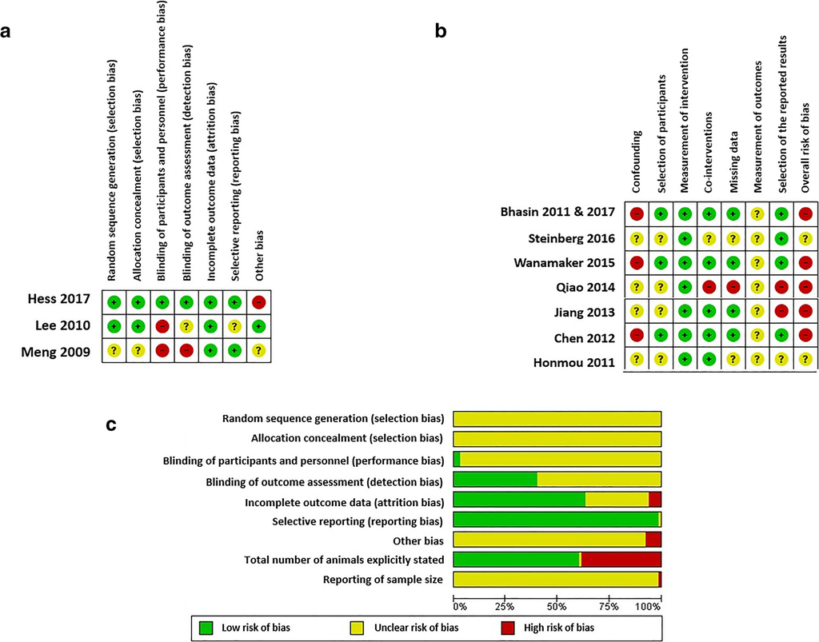

Transl. Stroke Res. (2020) 11:345–364

357

Risk of Bias

For clinical studies, the overall study quality was poor

For preclinical studies, the quality of studies was also found

to be poor, with the majority of studies at unclear risk of bias

due to poor methodological reporting (Fig. 2).

Construct Validity

In terms of construct validity, 56 studies (74%) stated that an

adult animal model was used, and three studies used animals

with comorbidities (4%). Fifty-seven studies (75%) demon-

strated persistent impairment in a control group, no studies

subjected animals to rehabilitation, and 28 studies (37%) used

a battery of sensory-motor recovery tests (as opposed to a

single test). In 21 studies (28%), the infarct size was propor-

tional to that seen in human stroke patients, and in 16 studies

(21%), the duration of occlusion created a clinically relevant

infarct size. A breakdown of construct validity by study, as

well as a more detailed outline of our criteria, is available in

Supplemental Table 2.

Safety of MSCs in the Clinical Setting

Nine studies (n = 339 patients) reported data on mortality,

three of which (n = 19 patients) were case series and were

therefore not included in the meta-analysis. Patients who had

been administered MSC therapy had a significantly reduced

risk of death compared to control (Peto OR 0.43; 95% CI

0.20–0.90) (Supplementary Fig. 1). The decrease in pooled

mortality was largely influenced by one study. In a sensitivity

analysis removing this study, there were an equal number of

deaths in each group (Peto OR 0.58; 95% CI 0.22–1.53)

(Supplemental Fig. 2). MSC treatment was associated with a

significantly increased risk of developing a fever immediately

following study injection (Peto OR 6.88; 95% CI 2.48–19.08).

There were no differences between groups in all other adverse

events reported (Supplemental Table 3). Of note, in the largest

RCT to date, similar rates of serious adverse events were seen

in the MSC group and control group (34% and 39%, respec-

tively) [15].

Safety of MSCs in the Preclinical Setting

Nine preclinical clinical studies (12%, n = 249 animals) reported

data on mortality. There was no statistically significant difference

in the risk of mortality between MSC and control groups (Peto

OR 0.96; 95% CI 0.49–1.86) (Supplemental Fig. 3).

Efficacy of MSCs in the Clinical Setting

Clinical measures of efficacy reported by studies in our

review included the NIHSS (n = 5, 50%), mRS (n = 6,

60%), BI (n = 3, 30%), Fugl-Meyer (FM) scale (n = 3,

30%), and the European Stroke Scale (ESS) (n = 1,

10%). Due to the heterogeneity of study designs, no for-

mal pooling of data was performed, and data is presented

descriptively. Of the five studies which reported data on

the NIHSS, there was one RCT [15], one single-arm trial

[7], one non-randomized interventional study [S6], and

two case series [S2, S8]. In the single RCT, there was

no significant difference in the NIHSS improvement be-

tween placebo and cell therapy groups at 1-year post-

treatment. In the single arm study, the NIHSS decreased

from baseline by 2.00 (95% CI, − 2.7 to − 1.3; P < 0.001)

at 12 months. In the non-randomized study, both treat-

ment and control groups saw a significant decrease in

the NIHSS scores at 6 months post-treatment; however,

the improvement seen in the MSC-treated group was sig-

nificantly larger. In both case series, the NIHSS scores

decreased post-treatment.

Of the six studies which reported data on mRS, there were

two RCTs [14, 15], one single-arm trial [7], and three case

series [S1–2, S8]. The first RCT reported that the proportion

of patients with an mRS score 0–3 increased in the MSC

group, but not in the control group. In the other RCT, the

proportion of patients with an mRS score ≤ 1 was significantly

larger in the MSC group at 1-year post-treatment (p = 0.041).

However, the authors stated that the distribution of mRS

scores was not significantly different between groups. In the

single-arm study, there was no change in mRS score from

baseline at 12 months post-treatment. In all three case series,

the mRS score decreased post-treatment.

Of the three studies which reported data on BI, one was an

RCT [15], one was a non-randomized study [S5], and one was a

case series [S2]. The RCT found that a BI of 95 or more was

equal between MSC and placebo-treated patients. In the non-

randomized study, the modified BI increased significantly more

in the treatment group compared to the control group at 208 and

156 weeks. In the case series, the BI increased post-treatment.

Of the three studies which reported data on FM score, there

was one RCT [S7], one single-arm study [7], and one non-

randomized study [S5]. In the RCT, the FM score improve-

ment was significantly greater in the treatment group com-

pared to the control group 6 months post-treatment. In the

single-arm study, the FM score increased significantly from

baseline at 12 months post-treatment. In the non-randomized

study, there was no significant difference in FM score between

treatment and control groups at 4-year follow-up.

One single-arm study reported data on European Stroke

Scale scores [7] and saw a significant increase from baseline

at 12 months post-treatment.

Transl. Stroke Res. (2020) 11:345–364

358

Efficacy of MSCs in the Preclinical Setting

Preclinical measures of efficacy reported by studies in our

review included the rotarod test (n = 19, 25%), the adhesive

removal test (n = 15, 20%), the modified neurological severity

score (n = 18, 24%), the skilled reaching test (n = 3, 4%), and

walking tasks (n = 4, 5%).

MSC therapy resulted in a significantly superior performance

compared to placebo-treated animals (Fig. 3a and b). Limited

data prohibited subgroup analyses for these outcomes.

Animals that had been treated with MSCs post stroke per-

formed significantly better on the adhesive removal test (MD

− 25.54; 95% CI − 30.39 to − 20.69, I<sup>2</sup>= 88.1%) (Fig. 3c)

when compared to placebo-treated animals. Visual inspection

of the funnel plot and Eggers regression test indicate a small

degree of publication bias (p = 0.011) (Supplemental Fig. 4).

In our a priori defined subgroup analyses, there was no differ-

ence in the measure of effect between species, or route of

administration (Supplemental Figs. 5–6). Animals that re-

ceived umbilical cord-derived MSCs performed better than

those that received either bone marrow-derived or adipose

tissue-derived MSCs (p < 0.001) (Supplemental Fig. 7).

Animals that received autologous MSCs (compared to alloge-

neic, syngeneic, or xenogeneic), received MSC therapy in 3–

30 days after stroke induction (compared to > 30 days), or had

stroke induced with the MCAO model (compared to

intraluminal suture or the Tamura model) performed worse

than their counterparts (Supplemental Figs. 8–10), although

limited evidence was available from those subgroups.

Animals who had been treated with MSCs performed sig-

nificantly better on the rotarod test (MD 25.12; 95% CI 17.34 to

32.90, I<sup>2</sup>= 91.1%) (Supplemental Fig. 11). No evidence of

publication bias was detected via visual inspection of a funnel

plot or via Egger’s regression test (Supplemental Fig. 12). In

post hoc exploratory subgroup analyses, there was no differ-

ence in the measure of effect between species, route of admin-

istration or stroke model (Supplemental Figs. 13–15). Animals

that had been administered adipose-derived MSCs (compared

to bone marrow or umbilical cord derived), or autologous

MSCs (compared to allogeneic, syngeneic or xenogeneic) per-

formed worse than their counterparts (Supplemental Figs. 16–

17), although limited evidence was available from those sub-

groups. No evidence was available from studies which admin-

istered MSCs > 30 days after stroke induction; therefore, that

subgroup analysis was not performed.

MSC-treated animals also had significantly lower modified

neurological severity scores (MD − 1.64; 95% CI − 2.18 to −

1.09) compared to placebo treated animals (Supplemental

Fig. 18). No evidence of publication bias was detected via

visual inspection of a funnel plot or via Egger’s regression test

(Supplemental Fig. 19). In post hoc exploratory subgroup

analyses, there was no difference in the measure of effect

between species, MSC source, route of administration, MSC

compatibility, or stroke model (Supplemental Figs. 20–24).

Animals that received MSC therapy 3–30 days after stroke

induction period performed better than those that received

MSC therapy > 30 days, although limited evidence was avail-

able for the chronic period (Supplemental Fig. 25).

Preclinical to Clinical Continuity of Evidence

In our citation analysis, the median number of preclinical

studies cited by each clinical study was 1 (range 0–4)

(Supplemental Table 4). Only two preclinical studies (3%)

were cited more than once. The consistency of evidence is

noted in our AERO model (Fig. 4). Evidence is overwhelm-

ingly positive (green) in the preclinical and early clinical

stages of research, with very few studies demonstrating any

unfavorable results. However, in the only randomized phase II

study to date (i.e., the most methodologically rigorous study)

[15], efficacy of MSC therapy was not observed.

Discussion

Our systematic review and meta-analysis evaluated and de-

scribed the safety and efficacy of MSC therapy for ischemic

stroke in both the clinical and preclinical settings. Our review

included 10 clinical and 76 preclinical studies, all of which

administered MSCs in either the subacute or chronic phase

following stroke. Available evidence indicates that MSC ther-

apy appears to be safe in both the preclinical and clinical

settings. In the preclinical setting, MSC therapy had beneficial

effects in multiple neurological and motor skills tests. In the

clinical setting, MSC therapy appeared to be promising in

early phase studies, but the most rigorous study performed

to date failed to demonstrate efficacy. We noted a clear dis-

continuity of effect as MSC therapy was translated from the

bench-to-bedside.

A complete and current synthesis of this area is needed at

this time for several reasons. From a patient perspective, pa-

tients seeking cell therapy from “stem cell clinics” (most com-

monly autologous bone marrow derived MSC therapy) should

be aware of the very limited current evidence to support effi-

cacy this therapy. For both preclinical and clinical researchers,

quantitative results from our study could be used to perform

power calculations for these studies as they are prepared.

Reassuringly for future trials, the therapy does appear to be

safe overall with no increase risk in mortality noted in clinical

studies. In addition, recognizing knowledge gaps and the dis-

continuity from preclinical to clinical development may in-

form better design of future preclinical and clinical studies.

Many potential reasons for the discordance between pre-

clinical and clinical findings can be found in our synthesized

Transl. Stroke Res. (2020) 11:345–364

359

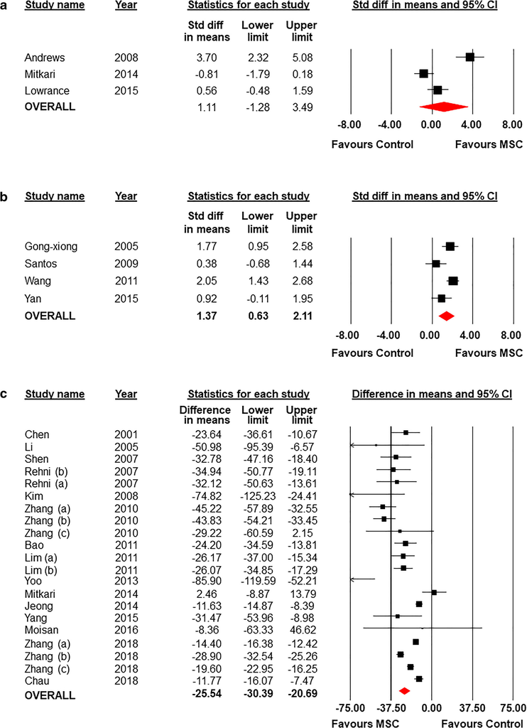

Transl. Stroke Res. (2020) 11:345–364

360

dataset. First, although MSC therapy for ischemic stroke has

been well studied in the preclinical setting, investigators have

focused on outcomes that may not be clinically relevant. For

example, in a 2014 meta-analysis of 46 studies of MSC ther-

apy for ischemic stroke in animal models, 44 studies reported

that MSC therapy significantly improved outcomes [31].

However, this study did not capture the most sensitive tests

of impairment that may be the most clinically relevant (e.g.,

reaching tasks) [23]. In our review, evidence was limited for

both walking (n = 4) and reaching (n = 3) tasks, and results

were marked with significant heterogeneity. The diminished

efficacy in the potentially most clinically relevant of tests may

provide insight into the lack of clinical efficacy in larger,

methodologically rigorous trials of MSC therapy. Future pre-

clinical studies should consider focusing on sensitive tests.

The timing of MSC therapy must be carefully considered

for future studies. All patients in clinical studies have been

administered MSC therapy in the subacute or chronic phase

following stroke; however, preclinical work cited by those

studies had focused on the acute administration of the cells.

In addition, a previous preclinical systematic review of MSC

therapy for stroke focused on acute administration of these

cells [31]. Our review now provides a synthesis of preclinical

studies that match the timing of clinical studies that have been

performed to date. It is clear, however, from our review that a

paucity of preclinical evidence exists for cell therapy in the

chronic phase of stroke (i.e., administration after 30 days in

stroke models), which is the timing of intervention for most

clinical trials performed to date. Future studies will need to

address this knowledge gap and use available clinical and

preclinical evidence to rationally choose the timing of cell

therapy. It may be possible that clinical studies will need to

focus on more acute administration of MSCs following stroke

in order to replicate the preclinical promise of this therapy.

The poor methodological rigor of both preclinical and early

clinical studies may have contributed to a high risk of bias in

their findings. For instance, only a small minority of preclinical

studies employed randomization and blinding, which are well

recognized to increase validity of findings (i.e., absence of these

methodologies spuriously increases the magnitude of outcomes

in preclinical studies) [32, 33]. Moreover, despite the large

number of studies published, it appears none of them were

specifically designed to be confirmatory studies, which are in-

creasingly considered to be a necessary preamble to clinical

trials [34, 35]. Similar issues with design were also noted for

clinical studies as the majority with positive results had signif-

icant issues with design (e.g., lack of blinding for outcome

assessment). Four of the ten clinical studies also did not include

a control group. The interpretation of data from these studies is

difficult, as the natural history for ischemic stroke is

ƒ<sup>Fig. 3</sup><sup>Standardized mean differences (95% CI) and pooled estimate for</sup><sup>a</sup>

skilled reaching test, b walking tasks, and difference in means (95% CI)

and pooled estimate for c adhesive removal tests

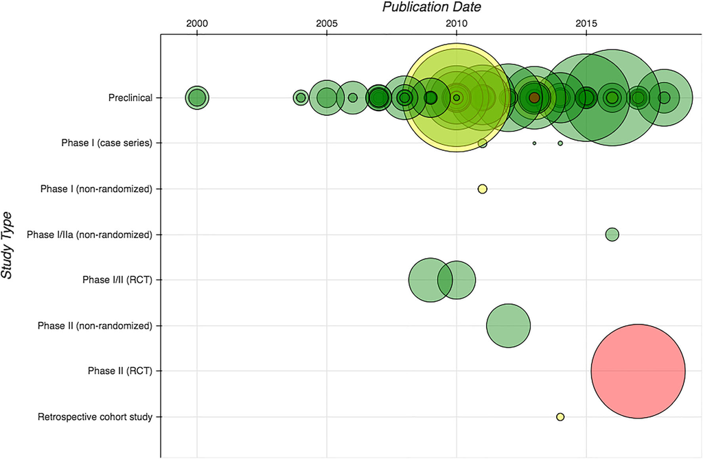

Fig. 4 AERO model demonstrating the consistency of results across the

translational pathway. The size of each circle is proportional to the sample

size of the study. A green circle represents a study with positive findings,

yellow represents mixed findings, and red represents negative findings

Transl. Stroke Res. (2020) 11:345–364

361

improvement with standard rehabilitation. It is perhaps not sur-

prising then that preclinical and clinical evidence is overwhelm-

ingly positive up to the point where MSC therapy was tested in

a methodologically rigorous manner (demonstrated through our

AERO diagram, Fig. 4). Increased methodological rigor will be

needed for future laboratory and clinical studies.

The clinical relevance of the stroke models used by many

of the included preclinical studies needs to be considered in

more detail. Studies have demonstrated that poor construct

validity affects reproducibility and downstream clinical trans-

lation [36, 37]. In our assessment of construct validity of in-

cluded preclinical studies, key characteristics seen in ischemic

stroke patients were missing or under-reported. For example,

up to 75% and 68% of ischemic stroke patients have hyper-

tension and hyperglycemia respectively, [38, 39] yet only

three included preclinical studies (4%) used animals with

any comorbidities. Additionally, only 16 (21%) of studies cre-

ated a clinically relevant infarct size by selecting an appropri-

ate duration of occlusion (i.e., < 90 min) and only 21 studies

(28%) infarcted less than 40% of the brain. The majority of

human strokes, especially the treatable ones, are significantly

smaller in size than what has been seen in preclinical models

[40, 41]. Severe differences between the preclinical experi-

mental conditions and the clinical manifestation of the disease

have been demonstrated to provide false estimates of effect

[28]. This may contribute to the discordance between the pre-

clinical and clinical evidence presented by this review. Future

preclinical studies should carefully consider parameters re-

garding their choice of animal model, in an effort to increase

construct validity.

Differences in donor cell characteristics may have also con-

tributed to differences in preclinical and clinical results. The

donors. However, in the clinical setting, half of the included

studies used an autologous MSC product. This may be signif-

icant as cell therapy products derived from non-healthy indi-

viduals have been demonstrated to be less efficacious than

those taken from healthy donors [42, 43]. The one large clin-

ical RCT included did use allogeneic cells from a healthy

donor; however, it did use a cryopreserved product and the

viability of cells post-thawing was not described. Issues with

poor viability of cryopreserved MSCs have been associated

with poor clinical efficacy [44]. In order to better match pre-

clinical conditions demonstrated to be efficacious, future clin-

ical trials should consider using allogeneic cells from healthy

donors (e.g., umbilical cord) and carefully assess (and report)

the viability of cells used.

Conclusions from our systematic review are limited by

several factors. First, our conclusions are tempered by the

across at least one domain. In addition, the majority of

preclinical studies were deemed to be at an unclear risk

of bias due to poor methodological reporting. Second,

there was considerable heterogeneity seen across studies.

Due to significant methodological heterogeneity seen in

clinical studies, no meta-analysis was performed. This

considerable heterogeneity precludes any definitive con-

clusions regarding efficacy; however, it does clearly dem-

onstrate the scarcity of data available. With regard to pre-

clinical studies, significant statistical heterogeneity was

observed across all performed analyses. Subgroup analy-

ses did not resolve any of the statistical heterogeneity

observed. Despite the observed limitations, this review

provides a comprehensive overview of all available data

concerning MSC therapy for ischemic stroke in both the

clinical and preclinical settings. Although some promising

results exist, it is evident from our review that high-

quality RCT evidence is required before conclusions can

be made regarding the efficacy of MSC therapy in the

chronic phase of ischemic stroke.

Summary

Our systematic review and meta-analysis provides a compre-

hensive, up-to-date evaluation of the safety and efficacy of

MSC therapy for chronic stroke. With the exception of an

increased risk in fever immediately following injection,

MSC therapy was not associated with an increase in adverse

events. Preclinically, MSC therapy demonstrated considerable

efficacy with regard to several neurological and motor func-

tion tests; however, in the most sensitive tests, signals of effi-

cacy were diminished. In the clinical setting, significant

methodologic heterogeneity and a scarcity of data precludes

definitive conclusions regarding efficacy of treatment, al-

though the largest and most methodologically sound trial to

date demonstrated a lack of efficacy. Future preclinical and

clinical studies should consider issues we have highlighted

including study design, methodological rigor, interventions,

and outcomes. Ultimately, well-designed RCTs examining

MSC therapy are needed to determine the effect of MSC ther-

apy in the treatment of chronic stroke.

Acknowledgments We would like to acknowledge Dr. Spencer Hey

(Harvard Center for Bioethics) for his assistance with the AERO model

and associated figure.

Compliance with Ethical Standards

Conflict of Interest

DS is an unpaid consultant and has an equity interest

in Northern Therapeutics (Montréal, QC, Canada).

Ethical Approval

This article does not contain any studies with human

participants or animals performed by any of the authors

Transl. Stroke Res. (2020) 11:345–364

362

References

1.

Global Health Estimates. Geneva: World Health Organization.

2012. http://www.who.int/healthinfo/global_burden_disease/en/.

Accessed November 26 2018.

2.

Shang W, Liu J. Stroke subtype classification: a comparative study

of ASCO and modified TOAST. J Neurol Sci. 2012;314(1–2):66–

70. https://doi.org/10.1016/j.jns.2011.10.029.

3.

Saver JL, Goyal M, van der Lugt A, Menon BK, Majoie CB, Dippel

DW, et al. Time to treatment with endovascular thrombectomy and

outcomes from ischemic stroke: a meta-analysis. JAMA.

2016;316(12):1279–88. https://doi.org/10.1001/jama.2016.13647.

4.

Biernaskie J, Chernenko G, Corbett D. Efficacy of rehabilitative

experience declines with time after focal ischemic brain injury. J

Neurosci. 2004;24(5):1245–54. https://doi.org/10.1523/

JNEUROSCI.3834-03.2004.

5.

Jorgensen HS, Nakayama H, Raaschou HO, Vive-Larsen J, Stoier

M, Olsen TS. Outcome and time course of recovery in stroke. Part

II: time course of recovery. The Copenhagen Stroke Study. Arch

Phys Med Rehabil. 1995;76(5):406–12.

6.

Duncan PW, Goldstein LB, Matchar D, Divine GW, Feussner J.

Measurement of motor recovery after stroke. Outcome assessment

and sample size requirements. Stroke. 1992;23(8):1084–9.

7.

Steinberg GK, Kondziolka D, Wechsler LR, Lunsford LD, Coburn

ML, Billigen JB, et al. Clinical outcomes of transplanted modified

bone marrow-derived mesenchymal stem cells in stroke: a phase 1/

2a study. Stroke. 2016;47(7):1817–24. https://doi.org/10.1161/

STROKEAHA.116.012995.

8.

Crisan M, Yap S, Casteilla L, Chen CW, Corselli M, Park TS, et al.

A perivascular origin for mesenchymal stem cells in multiple hu-

man organs. Cell Stem Cell. 2008;3(3):301–13. https://doi.org/10.

1016/j.stem.2008.07.003.

9.

da Silva ML, Caplan AI, Nardi NB. In search of the in vivo identity

of mesenchymal stem cells. Stem Cells. 2008;26(9):2287–99.

https://doi.org/10.1634/stemcells.2007-1122.

10.

Huang W, Mo X, Qin C, Zheng J, Liang Z, Zhang C.

Transplantation of differentiated bone marrow stromal cells pro-

motes motor functional recovery in rats with stroke. Neurol Res.

2013;35(3):320–8. https://doi.org/10.1179/1743132812Y.

0000000151.

11.

Tohill M, Mantovani C, Wiberg M, Terenghi G. Rat bone marrow

mesenchymal stem cells express glial markers and stimulate nerve

regeneration. Neurosci Lett. 2004;362(3):200–3. https://doi.org/10.

1016/j.neulet.2004.03.077.

12.

Liu Z, Li Y, Zhang L, Xin H, Cui Y, Hanson LR, et al. Subacute

intranasal administration of tissue plasminogen activator increases

functional recovery and axonal remodeling after stroke in rats.

Neurobiol Dis. 2012;45(2):804–9. https://doi.org/10.1016/j.nbd.

2011.11.004.

13.

Yoo KH, Jang IK, Lee MW, Kim HE, Yang MS, Eom Y, et al.

Comparison of immunomodulatory properties of mesenchymal

stem cells derived from adult human tissues. Cell Immunol.

2009;259(2):150–6. https://doi.org/10.1016/j.cellimm.2009.06.

010.

14.

Lee JS, Hong JM, Moon GJ, Lee PH, Ahn YH, Bang OY, et al. A

long-term follow-up study of intravenous autologous mesenchymal

stem cell transplantation in patients with ischemic stroke. Stem

Cells. 2010;28(6):1099–106. https://doi.org/10.1002/stem.430.

15.

Hess DC, Wechsler LR, Clark WM, Savitz SI, Ford GA, Chiu D,

et al. Safety and efficacy of multipotent adult progenitor cells in

acute ischaemic stroke (MASTERS): a randomised, double-blind,

placebo-controlled, phase 2 trial. Lancet Neurol. 2017;16(5):360–8.

https://doi.org/10.1016/S1474-4422(17)30046-7.

16.

Du L, Rachul C, Guo Z, Caulfield T. Gordie Howe’s “miraculous

treatment”: case study of twitter Users' reactions to a sport

Celebrity's stem cell treatment. JMIR Public Health Surveill.

2016;2(1):e8. https://doi.org/10.2196/publichealth.5264.

17.

Connolly R, O'Brien T, Flaherty G. Stem cell tourism–a web-based

analysis of clinical services available to international travellers.

Travel Med Infect Dis. 2014;12(6 Pt B):695–701. https://doi.org/

10.1016/j.tmaid.2014.09.008.

18.

Moher D, Liberati A, Tetzlaff J, Altman DG, Group P. Preferred

reporting items for systematic reviews and meta-analyses: the

PRISMA statement. BMJ. 2009;339:b2535. https://doi.org/10.

1136/bmj.b2535.

19.

Dominici M, Le Blanc K, Mueller I, Slaper-Cortenbach I, Marini F,

Krause D, et al. Minimal criteria for defining multipotent mesen-

chymal stromal cells. The International Society for Cellular

Therapy position statement. Cytotherapy. 2006;8(4):315–7.

https://doi.org/10.1080/14653240600855905.

20.

Quinn TJ, Langhorne P, Stott DJ. Barthel index for stroke trials:

development, properties, and application. Stroke. 2011;42(4):1146–

51. https://doi.org/10.1161/STROKEAHA.110.598540.

21.

Lyden P, Raman R, Liu L, Emr M, Warren M, Marler J. National

Institutes of Health Stroke Scale certification is reliable across mul-

tiple venues. Stroke. 2009;40(7):2507–11. https://doi.org/10.1161/

STROKEAHA.108.532069.

22.

Wilson JT, Hareendran A, Grant M, Baird T, Schulz UG, Muir KW,

et al. Improving the assessment of outcomes in stroke: use of a

structured interview to assign grades on the modified Rankin scale.

Stroke. 2002;33(9):2243–6.

23.

Schaar KL, Brenneman MM, Savitz SI. Functional assessments in

the rodent stroke model. Exp Transl Stroke Med. 2010;2(1):13.

https://doi.org/10.1186/2040-7378-2-13.

24.

Balkaya MG, Trueman RC, Boltze J, Corbett D, Jolkkonen J.

Behavioral outcome measures to improve experimental stroke re-

search. Behav Brain Res. 2018;352:161–71. https://doi.org/10.

1016/j.bbr.2017.07.039.

25.

Corbett D, Carmichael ST, Murphy TH, Jones TA, Schwab ME,

Jolkkonen J, et al. Enhancing the alignment of the preclinical and

clinical stroke recovery research pipeline: consensus-based core

recommendations from the Stroke Recovery and Rehabilitation

Roundtable translational working group. Int J Stroke. 2017;12(5):

462–71. https://doi.org/10.1177/1747493017711814.

26.

McGowan J, Sampson M, Salzwedel DM, Cogo E, Foerster V,

Lefebvre C. PRESS peer review of electronic search strategies:

2015 guideline statement. J Clin Epidemiol. 2016;75:40–6.

https://doi.org/10.1016/j.jclinepi.2016.01.021.

27.

Lalu MM, Sullivan KJ, Mei SH, Moher D, Straus A, Fergusson

DA, et al. Evaluating mesenchymal stem cell therapy for sepsis with

preclinical meta-analyses prior to initiating a first-in-human trial.

Elife. 2016;5. https://doi.org/10.7554/eLife.17850.

28.

Henderson VC, Kimmelman J, Fergusson D, Grimshaw JM,

Hackam DG. Threats to validity in the design and conduct of pre-

clinical efficacy studies: a systematic review of guidelines for

in vivo animal experiments. PLoS Med. 2013;10(7):e1001489.

https://doi.org/10.1371/journal.pmed.1001489.

29.

Brockhaus AC, Grouven U, Bender R. Performance of the Peto

odds ratio compared to the usual odds ratio estimator in the case

of rare events. Biom J. 2016;58(6):1428–44. https://doi.org/10.

1002/bimj.201600034.

30.

Hey SP, Heilig CM, Weijer C. Accumulating Evidence and

Research Organization (AERO) model: a new tool for representing,

analyzing, and planning a translational research program. Trials.

2013;14:159. https://doi.org/10.1186/1745-6215-14-159.

31.

Vu Q, Xie K, Eckert M, Zhao W, Cramer SC. Meta-analysis of

preclinical studies of mesenchymal stromal cells for ischemic

stroke. Neurology. 2014;82(14):1277–86. https://doi.org/10.1212/

WNL.0000000000000278.

32.

Hirst JA, Howick J, Aronson JK, Roberts N, Perera R, Koshiaris C,

et al. The need for randomization in animal trials: an overview of

Transl. Stroke Res. (2020) 11:345–364

363

systematic reviews. PLoS One. 2014;9(6):e98856. https://doi.org/

10.1371/journal.pone.0098856.

33.

Macleod MR, van der Worp HB, Sena ES, Howells DW, Dirnagl U,

Donnan GA. Evidence for the efficacy of NXY-059 in experimental

focal cerebral ischaemia is confounded by study quality. Stroke.

2008;39(10):2824–9. https://doi.org/10.1161/STROKEAHA.108.

515957.

34.

Mogil JS, Macleod MR. No publication without confirmation.

Nature. 2017;542(7642):409–11. https://doi.org/10.1038/542409a.

35.

Chamuleau SAJ, van der Naald M, Climent AM, Kraaijeveld AO,

Wever KE, Duncker DJ, et al. Translational research in cardiovas-

cular repair: a call for a paradigm shift. Circ Res. 2018;122(2):310–

8. https://doi.org/10.1161/CIRCRESAHA.117.311565.

36.

Scott S, Kranz JE, Cole J, Lincecum JM, Thompson K, Kelly N,

et al. Design, power, and interpretation of studies in the standard

murine model of ALS. Amyotroph Lateral Scler. 2008;9(1):4–15.

https://doi.org/10.1080/17482960701856300.

37.

Reynolds JC, Rittenberger JC, Menegazzi JJ. Drug administration

in animal studies of cardiac arrest does not reflect human clinical

experience. Resuscitation. 2007;74(1):13–26. https://doi.org/10.

1016/j.resuscitation.2006.10.032.

38.

van der Worp HB, Raaijmakers TW, Kappelle LJ. Early complica-

tions of ischemic stroke. Curr Treat Options Neurol. 2008;10(6):

440–9.

39.

van der Worp HB, van Gijn J. Clinical practice. Acute ischemic

stroke. N Engl J Med. 2007;357(6):572–9. https://doi.org/10.

1056/NEJMcp072057.

40.

Brott T, Marler JR, Olinger CP, Adams HP Jr, Tomsick T, Barsan

WG, et al. Measurements of acute cerebral infarction: lesion size by

computed tomography. Stroke. 1989;20(7):871–5. https://doi.org/

10.1161/01.str.20.7.871.

41.

Lyden PD, Zweifler R, Mahdavi Z, Lonzo L. A rapid, reliable, and

valid method for measuring infarct and brain compartment volumes

from computed tomographic scans. Stroke. 1994;25(12):2421–8.

https://doi.org/10.1161/01.str.25.12.2421.

42.

van de Vyver M. Intrinsic mesenchymal stem cell dysfunction in

diabetes mellitus: implications for autologous cell therapy. Stem

Cells Dev. 2017;26(14):1042–53. https://doi.org/10.1089/scd.

2017.0025.

43.

Block TJ, Marinkovic M, Tran ON, Gonzalez AO, Marshall A,

Dean DD, et al. Restoring the quantity and quality of elderly human

mesenchymal stem cells for autologous cell-based therapies. Stem

Cell Res Ther. 2017;8(1):239. https://doi.org/10.1186/s13287-017-

0688-x.

44.

Matthay MA, Calfee CS, Zhuo H, Thompson BT, Wilson JG, Levitt

JE, et al. Treatment with allogeneic mesenchymal stromal cells for

moderate to severe acute respiratory distress syndrome (START

study): a randomised phase 2a safety trial. Lancet Respir Med.

2019;7(2):154–62. https://doi.org/10.1016/S2213-2600(18)30418-1.

Publisher’s Note Springer Nature remains neutral with regard to jurisdic-

tional claims in published maps and institutional affiliations.

Transl. Stroke Res. (2020) 11:345–364

364